# Ch03 6_4 Boston

Bruce Hartman

University of St. Francis

2026-09-06 Revised 2026-10-15T09:02:14

Abstract

We follow Chapter 3 lab Section 6.4 of ISLR, in an R Notebook using modern tidyverse methods, performing a simple regression on the `Boston` dataset with interaction terms.

# Introduction

We deal with regression and analysis of the `Boston` dataset from the `ISLR2` package, focusing on a simple regression, of target `medv` on driver `lstat` with interactions. We run the regression, interpret it and look at residuals. We will follow the ISLR textbook, Chapter 3.

# Packages

We make the `mbadtools` required packages available, and also load the `ISLR2` package for data.

```
library(ISLR2) # for the course data
# load github packages
library(mbadtools, quietly = TRUE)
```

# Data

We have seen this before.

```
data(Boston)
Boston %>% skim
```

```
── Data Summary ────────────────────────
                           Values
Name                       Piped data
Number of rows             506
Number of columns          14
_______________________
Column type frequency:
  numeric                  14
________________________
Group variables            None
```

|  | skim_variable | n_missing | complete_rate | mean | sd | p0 | p25 | p50 | p75 | p100 | hist |
| --- | --- | --- | --- | --- | --- | --- | --- | --- | --- | --- | --- |
| 1 | crim | 0 | 1 | 3.61352356 | 8.6015451 | 0.00632 | 0.082045 | 0.25651 | 3.677083 | 88.9762 | ▇▁▁▁▁ |
| 2 | zn | 0 | 1 | 11.36363636 | 23.3224530 | 0.00000 | 0.000000 | 0.00000 | 12.500000 | 100.0000 | ▇▁▁▁▁ |
| 3 | indus | 0 | 1 | 11.13677866 | 6.8603529 | 0.46000 | 5.190000 | 9.69000 | 18.100000 | 27.7400 | ▇▆▁▇▁ |
| 4 | chas | 0 | 1 | 0.06916996 | 0.2539940 | 0.00000 | 0.000000 | 0.00000 | 0.000000 | 1.0000 | ▇▁▁▁▁ |
| 5 | nox | 0 | 1 | 0.55469506 | 0.1158777 | 0.38500 | 0.449000 | 0.53800 | 0.624000 | 0.8710 | ▇▇▆▅▁ |
| 6 | rm | 0 | 1 | 6.28463439 | 0.7026171 | 3.56100 | 5.885500 | 6.20850 | 6.623500 | 8.7800 | ▁▂▇▂▁ |
| 7 | age | 0 | 1 | 68.57490119 | 28.1488614 | 2.90000 | 45.025000 | 77.50000 | 94.075000 | 100.0000 | ▂▂▂▃▇ |
| 8 | dis | 0 | 1 | 3.79504269 | 2.1057101 | 1.12960 | 2.100175 | 3.20745 | 5.188425 | 12.1265 | ▇▅▂▁▁ |
| 9 | rad | 0 | 1 | 9.54940711 | 8.7072594 | 1.00000 | 4.000000 | 5.00000 | 24.000000 | 24.0000 | ▇▂▁▁▃ |
| 10 | tax | 0 | 1 | 408.23715415 | 168.5371161 | 187.00000 | 279.000000 | 330.00000 | 666.000000 | 711.0000 | ▇▇▃▁▇ |

[output cut: 4 more lines]

# Regression

We will run a regression with interactions of `medv` on `lstat` and `age`, using the `lm()` function to do it. We will also use the `broom` package to tidy up the output, and the `ggplot2` package for plotting. The `gt_add_significance()` function produces a nicely formatted table with significant p-values colored to be seen easily. Notice the * between `lstat` and `age` which adds the interactions.

```
lm.fitint=lm(medv~lstat*age,data=Boston)
lm.fitint %>% summary()
```

```
Call:
lm(formula = medv ~ lstat * age, data = Boston)

Residuals:
    Min      1Q  Median      3Q     Max
-15.806  -4.045  -1.333   2.085  27.552

Coefficients:
              Estimate Std. Error t value Pr(>|t|)
(Intercept) 36.0885359  1.4698355  24.553  < 2e-16 ***
lstat       -1.3921168  0.1674555  -8.313 8.78e-16 ***
age         -0.0007209  0.0198792  -0.036   0.9711
lstat:age    0.0041560  0.0018518   2.244   0.0252 *
---
Signif. codes:  0 ‘***’ 0.001 ‘**’ 0.01 ‘*’ 0.05 ‘.’ 0.1 ‘ ’ 1

Residual standard error: 6.149 on 502 degrees of freedom
Multiple R-squared:  0.5557,    Adjusted R-squared:  0.5531
F-statistic: 209.3 on 3 and 502 DF,  p-value: < 2.2e-16
```

```
lm.fitint %>% glance %>% gt_add_significance()  %>% fmt_number()
```

| r.squared | adj.r.squared | sigma | statistic | p.value | df | logLik | AIC | BIC | deviance | df.residual | nobs |
| --- | --- | --- | --- | --- | --- | --- | --- | --- | --- | --- | --- |
| 0.56 | 0.55 | 6.15 | 209.31 | 0.00 | 3.00 | −1,634.98 | 3,279.95 | 3,301.09 | 18,977.72 | 502.00 | 506.00 |

```
lm.fitint %>% tidy(conf.int=TRUE) %>% gt_add_significance() %>% fmt_number()
```

| term | estimate | std.error | statistic | p.value | conf.low | conf.high |
| --- | --- | --- | --- | --- | --- | --- |
| (Intercept) | 36.09 | 1.47 | 24.55 | 0.00 | 33.20 | 38.98 |
| lstat | −1.39 | 0.17 | −8.31 | 0.00 | −1.72 | −1.06 |
| age | 0.00 | 0.02 | −0.04 | 0.97 | −0.04 | 0.04 |
| lstat:age | 0.00 | 0.00 | 2.24 | 0.03 | 0.00 | 0.01 |

Residuals are always important.

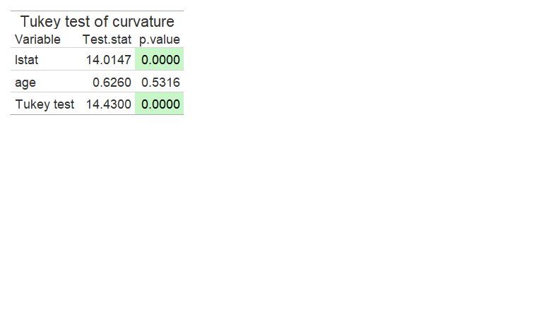

# Only the interaction

```
lm.fitint1=lm(medv ~ lstat + lstat:age,data=Boston)
lm.fitint1 %>% summary()
```

```
Call:
lm(formula = medv ~ lstat + lstat:age, data = Boston)

Residuals:
    Min      1Q  Median      3Q     Max
-15.815  -4.039  -1.335   2.086  27.491

Coefficients:
             Estimate Std. Error t value Pr(>|t|)
(Intercept) 36.041514   0.691334  52.133  < 2e-16 ***
lstat       -1.388161   0.126911 -10.938  < 2e-16 ***
lstat:age    0.004103   0.001133   3.621 0.000324 ***
---
Signif. codes:  0 ‘***’ 0.001 ‘**’ 0.01 ‘*’ 0.05 ‘.’ 0.1 ‘ ’ 1

Residual standard error: 6.142 on 503 degrees of freedom
Multiple R-squared:  0.5557,    Adjusted R-squared:  0.554
F-statistic: 314.6 on 2 and 503 DF,  p-value: < 2.2e-16
```

```
lm.fitint1 %>% glance %>% gt_add_significance()  %>% fmt_number()
```

| r.squared | adj.r.squared | sigma | statistic | p.value | df | logLik | AIC | BIC | deviance | df.residual | nobs |
| --- | --- | --- | --- | --- | --- | --- | --- | --- | --- | --- | --- |
| 0.56 | 0.55 | 6.14 | 314.59 | 0.00 | 2.00 | −1,634.98 | 3,277.96 | 3,294.86 | 18,977.77 | 503.00 | 506.00 |

```
lm.fitint1 %>% tidy(conf.int=TRUE) %>% gt_add_significance() %>% fmt_number()
```

| term | estimate | std.error | statistic | p.value | conf.low | conf.high |
| --- | --- | --- | --- | --- | --- | --- |
| (Intercept) | 36.04 | 0.69 | 52.13 | 0.00 | 34.68 | 37.40 |
| lstat | −1.39 | 0.13 | −10.94 | 0.00 | −1.64 | −1.14 |
| lstat:age | 0.00 | 0.00 | 3.62 | 0.00 | 0.00 | 0.01 |

```
lm.fitint1 %>% gg_residual_plots()
```

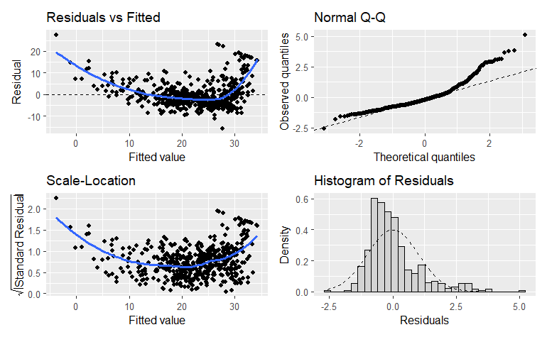

Still some problems.

# Conclusion

We ran a regression of `medv` using `Boston` data with an interaction term. And we did the same with only `lstat` and the interaction with `age`.

# References

1. ISLR (2013) Chapter 3 Section 3.6.2 Simple Linear Regression, page 110ff.